# Workshop on Experimental Design & Data Analysis

Topic: Data Types

Priscila Lopez-Beltran Forcada, Ph.D.

Updated on July, 2023

## In this workshop, we will cover a series of basic concepts that are crucial to better understand how to design, implement and analyze experimental results. Having a thorough understanding of the characteristics of different types of data, which will be critical before moving on to more advanced topics such as experimental design and data analysis.

### Data types

Why is understanding the difference between data types important? Understanding the characteristics of different data types grants us a deeper understanding of (1) the nature of the variables, and (2) the interpretation of results.

The most important difference is betweeen quantitative data and qualitative data. Here is a breakdown with examples:

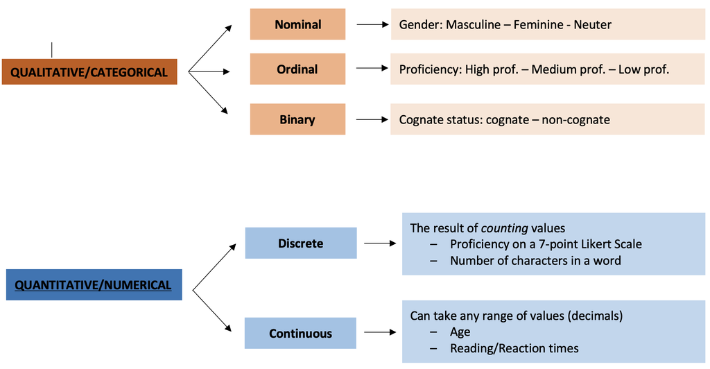

Let’s now try to identify these data types in a real-life *Language History Questionnaire* data sample

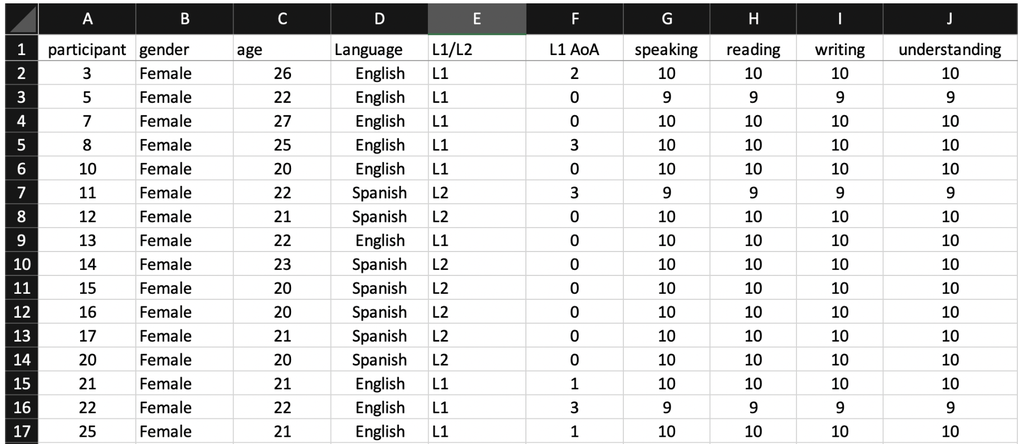

### Categorical vs. Continuous data

Handling continuous data is pretty straight forward, we can apply all types of mathematical functions to them. For example, let see the data set `starwars` in the package `dplyr`. This data set contains variables of many kinds, let’s identify a continuous variable.

```
## # A tibble: 6 × 14
##   name      height  mass hair_color skin_color eye_color birth_year sex   gender
##   <chr>      <int> <dbl> <chr>      <chr>      <chr>          <dbl> <chr> <chr>
## 1 Luke Sky…    172    77 blond      fair       blue            19   male  mascu…
## 2 C-3PO        167    75 <NA>       gold       yellow         112   none  mascu…
## 3 R2-D2         96    32 <NA>       white, bl… red             33   none  mascu…
## 4 Darth Va…    202   136 none       white      yellow          41.9 male  mascu…
## 5 Leia Org…    150    49 brown      light      brown           19   fema… femin…
## 6 Owen Lars    178   120 brown, gr… light      blue            52   male  mascu…
## # ℹ 5 more variables: homeworld <chr>, species <chr>, films <list>,
## #   vehicles <list>, starships <list>
```

For instance:

- Continuous: height

Here we can ask, what is the mean height of all characters?

```r
summary(starwars$height)
```

```
##    Min. 1st Qu.  Median    Mean 3rd Qu.    Max.    NA's
##    66.0   167.0   180.0   174.4   191.0   264.0       6
```

However, what if we tried to do the same with a categorical variable?

- Categorical: gender

```r
summary(starwars$gender)
```

```
##    Length     Class      Mode
##        87 character character
```

We cannot ask R to give us the mean gender of all characters, and because it reads the vector as class *character* it won’t tell us much. What we learn from this is that it is **absolutely crucial** to understand the types of variables in our data sets. Not all data are created equal and treatments may be necessary when we deal with variables that belong to certain data types.

### **Now you do it**

- Download the Rling package by Levshina (2015) https://github.com/levshina/BookMaterials
- Install it: Tools > Install Packages > Package Archive file
- Type in `r, data(sharedref)`

You will be working on a data set with experimental data on shared reference expressions in Nicaraguan Sign Language:

- Identify the continuous and categorical variables.
- Create and implement a coding scheme for the categorical variable(s)

**Answer**

- Continuous:
  - mod
- Categorical
  - age
  - cohort

**Answer**

For example, Age:

- Early = 0
- Middle = 1
- Late = 2

### Resources for extra reading

- Reading for next session:
  - Arunachalam (2013) Experimental Methods for Linguists https://www.researchgate.net/publication/263085613_Experimental_Methods_for_Linguists
- This corresponds to Andy Fields’ book Chapter 1.5
- Types of data
  - https://www.chi2innovations.com/blog/discover-data-blog-series/data-types-101/
- Dummy coding
  - https://stats.idre.ucla.edu/spss/faq/coding-systems-for-categorical-variables-in-regression-analysis-2/#:~:text=Perhaps%20the%20simplest%20and%20perhaps,of%20zero%20or%20one%20only.)
  - https://stats.idre.ucla.edu/r/modules/coding-for-categorical-variables-in-regression-models/
- Types of elements in R
  - https://www.statmethods.net/input/datatypes.html
  - https://www.datacamp.com/community/tutorials/data-types-in-r